# Homework 1: Graphs

Alessandro Quattrociocchi - Juan Mata Narajo

# Part A ~ Max Cut Algorithm

In this homework we report some results obtained by studying graphs.  
In the first case, we studied the problem of the maxcut().We want to obtain a set, a subset of summits, that has the highest possible cardinality. Our aim was to verify some algorithms that allow us a good estimate of maxcut().  
For this reason we report at the beginning some theoretical aspects that we used to implement the algorithm that estimated maxcut().

For each set of vertexes U, a subset of V, we define **cut** the set given by:
$$\begin{align}
\delta(U) = {{u,v} \in E} \quad \textit{such that} \quad {u \in U } \quad {v \notin V}
\end{align}$$

The maxcut problem is then to solve:
$$\begin{align}
\textit{max}[card(\delta(U))] \quad \textit{for} \quad U \subseteq V
\end{align}$$

Defined OPT the maximum number of cuts we can make on graph g, our goal is to approximate this value with the following algorithm. Given a factor $\alpha$ positive and independent from graph G, such that the set has the following property:

$$\begin{align}
card((\delta(U)) >= \alpha \quad x \quad \textbf{OPT}
\end{align}$$

### How we proof the inequality

At the beginning we created a small graph using the igraph package, that allowed us to generate graphs either from adjacency matrix either taping into graph as an object. After having generated and tested this algorithm on the first graph, we extended this algorithm to some randomly generated graphs according to the Erdos-Renyi model.  
The workflow has been organized in the following way:

1. Generate a random graph
2. Calculate the adjacency matrix for the generated graph
3. Find the maxcut() using the default function with the adjacency matrix as input
4. For each maxcut() value check the inequality

To this end, we have created four functions which we will describe below:

## Function 1: Random graph function

Our aim was to extend this type of analysis to any graph with different numbers of vertexes and connections, not to one in particular. Then we created a function that receives as input the number of vertexes of the graph and the probability of connections. Given a number of vertexes and the probability of links, the function generates a graph with the Erdős–Rényi model in the version theorized by Edgar Gilbert.

```r
library (igraph)
library (ggraph)
library(sdpt3r)
getrandomgraph = function(n_vertex, link_prob) {

  if (link_prob < 0 | link_prob > 1) {
    stop ("Probability must be in [0,1] ")
  }


  g <- erdos.renyi.game(n_vertex, link_prob )

  degree_distribution(g)
  E(g)$color = "black"
  plot(g, vertex.color="yellow", vertex.size=13,
       vertex.frame.color="black", vertex.label.color="black",
       vertex.label.cex=0.8, edge.curved=0)

  return(g)
}
```

## Function 2: Construct randomized algorithm

This second function can be considered the heart of the algorithm.  
Starting from the V set, for all the vertexes in V, a coin is flipped and according on the result,  
that vertex could be added or not to the U subset.  
As output, we have a list that contains all the vertexes added to the U set.

```r
randomized_max_cut = function(adjacency_matrix) {

#adjacency_matrix -> Matrix including all vertexes and links between vertexes

#First we will generate a random subset from the vertexes sample

vertices = 1:nrow(adjacency_matrix)
vertices_subset = sample(c(0, 1),
                           replace = TRUE,
                           size = nrow(adjacency_matrix)) * (vertices)
vertices_subset = vertices_subset[vertices_subset != 0]

#Once we have the vertexes subset (U) we have to compute the number of cuts.
#Given that the adjacency matrix is symmetric, we will only be interested in upper diagonal part.


num_cuts = 0
cutted_edges = rep(NA, 1)
for (row in 1:length(vertices)) {
  for (col in seq(row+1:length(vertices))) {
    if (adjacency_matrix[row, col] == 1) {
# A cut exists if, between the linked vertexes, one is contained in U and the other is not contained in U
      if ((col %in% vertices_subset)*!(row %in% vertices_subset)) {
        num_cuts = num_cuts + 1
        cutted_edges = append(cutted_edges, paste0(col, '-', row))
        }
      }
    }
  }
  output = list('num_cuts' = num_cuts,
                'cutted_edges' = cutted_edges[!is.na(cutted_edges)])
  return(output)
}
```

## Function 3: Evaluate the performance of the randomized algorithm against the optimal max-cut values

This function verifies inequality, has as input the number of simulations, the graph g adjacency matrix and the optimal maxcut() number.  
Below, we have tested the performance of this algorithm and graphed the trend of the average number of the maxcut(), as a function of the iterations.

```r
max_cut_simulation_run = function(number_of_simulations, adjacency_matrix,
                                  optimal_max_cut, print=TRUE) {

  num_cuts = 0
  for (sim in 1:number_of_simulations) {
    num_cuts = num_cuts + randomized_max_cut(adjacency_matrix = adjacency_matrix)$num_cuts
  }
  algorithm_performance = num_cuts/number_of_simulations
  if (print) {
    if (algorithm_performance >= optimal_max_cut/2) {
      print('The randomazied max cut algorithm average is higher than half of the optimal max cut value')
    } else {
      print('The randomazied max cut algorithm average is lower than half of the optimal max cut value')
    }
  }
  return(algorithm_performance)
}
```

## Function 4: Show Cuts in graph

This last function highlights the edges for all the vertexes in the subset U.

```r
show_cuts_in_graph = function(g, cuts) {

  edges_list = as_edgelist(g)
  E(g)$width = 1
  E(g)$color = "black"
  for (cutted_edges in 1:length(cuts)) {
    for (graph_edges in seq(1, length(edges_list)/2)) {
      if (all(as.numeric(unlist(strsplit(cuts[cutted_edges], '-'))) == edges_list[graph_edges,]) |
          all(as.numeric(unlist(strsplit(cuts[cutted_edges], '-'))) == rev(edges_list[graph_edges,]))) {

        E(g)$width[graph_edges] = 5
        E(g)$color[graph_edges] = "red"
        break
      }
    }
  }
  plot(g, vertex.color="yellow", vertex.size=13,
       vertex.frame.color="black", vertex.label.color="black",
       vertex.label.cex=0.8, edge.curved=0)

}
```

## Simulation results

In this part we report the simulations and comments.

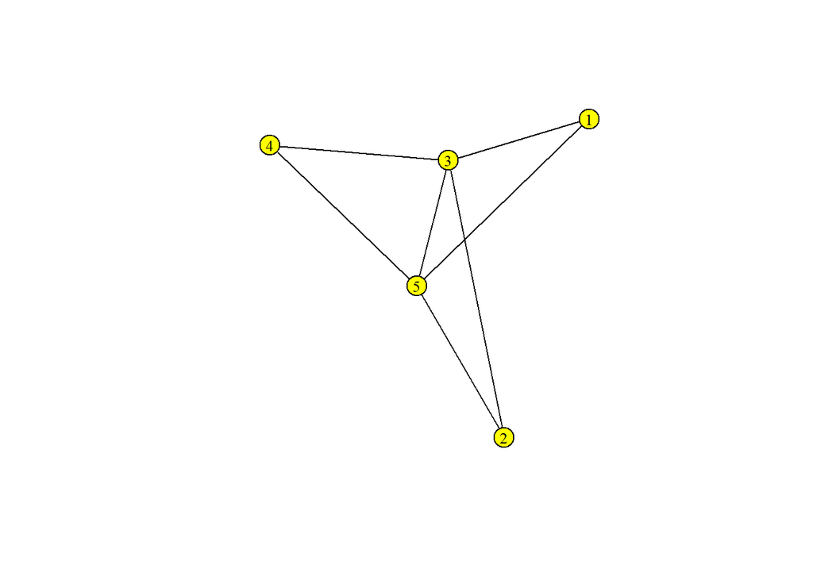

```r
g1 = getrandomgraph(5, 0.8)
```

```r
# 2. Construct adjacency matrix from graph g1
# Assuming that the adjacency matrix is necessarily squared
num_columns = length(g1[1])
num_rows = num_columns
adjacency_matrix = matrix(NA, nrow = num_rows, ncol = num_columns)
for (r in 1:num_rows) {
  adjacency_matrix[r,] = g1[r]
}
```

```r
print(adjacency_matrix)
```

```
##      [,1] [,2] [,3] [,4] [,5]
## [1,]    0    0    1    0    1
## [2,]    0    0    1    0    1
## [3,]    1    1    0    1    1
## [4,]    0    0    1    0    1
## [5,]    1    1    1    1    0
```

```r
 # 3. Construct theoretical optimal max cut value
# Based on the adjacency matrix, obtain the theoretical optimal max cut value
out <- maxcut(adjacency_matrix)
optimal_max_cut = -out$pobj
print(optimal_max_cut)
```

```
## [1] 6
```

```r
# 4. Run simulation to see whether our randomized max cut algorithm also gets goods results

max_cut_simulation_run(number_of_simulations = 20,
                       adjacency_matrix = adjacency_matrix,
                       optimal_max_cut = optimal_max_cut)
```

```
## [1] "The randomazied max cut algorithm average is higher than half of the optimal max cut value"
```

```
## [1] 3.4
```

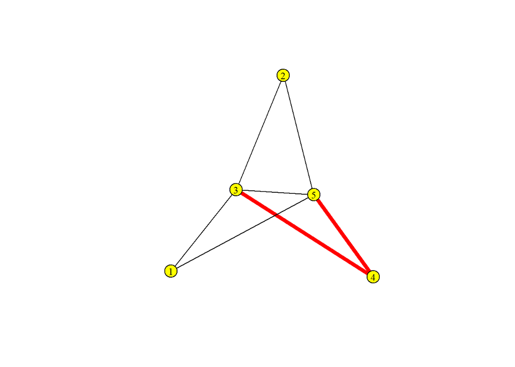

```r
# 5. Show cuts in the graph

cuts = randomized_max_cut(adjacency_matrix = adjacency_matrix)$cutted_edges
show_cuts_in_graph(g1, cuts)
```

## Simulation with n=10 and p=0.5

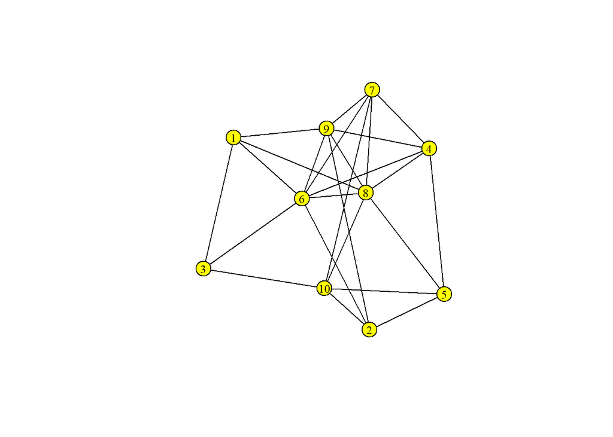

```r
g1 = getrandomgraph(10, 0.5)
```

```r
num_columns = length(g1[1])
num_rows = num_columns
adjacency_matrix = matrix(NA, nrow = num_rows, ncol = num_columns)
for (r in 1:num_rows) {
  adjacency_matrix[r,] = g1[r]
}
#for these iterations we do not print the adjacency matrix because it could be large
#print(adjacency_matrix)

out <- maxcut(adjacency_matrix)
optimal_max_cut = -out$pobj
print(optimal_max_cut)
```

```
## [1] 18.61149
```

```r
max_cut_simulation_run(number_of_simulations = 20,
                       adjacency_matrix = adjacency_matrix,
                       optimal_max_cut = optimal_max_cut)
```

```
## [1] "The randomazied max cut algorithm average is higher than half of the optimal max cut value"
```

```
## [1] 12.75
```

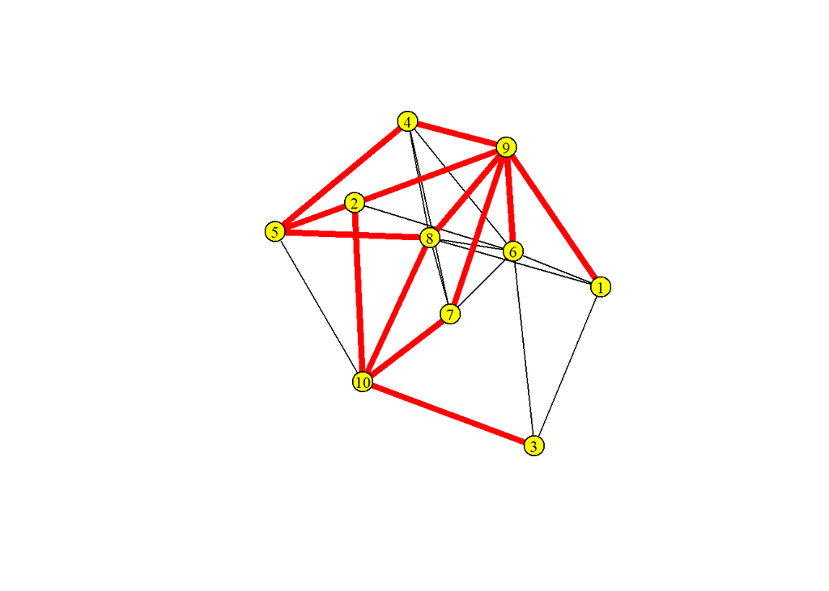

```r
cuts = randomized_max_cut(adjacency_matrix = adjacency_matrix)$cutted_edges
show_cuts_in_graph(g1, cuts)
```

## Simulation with n=20 and p=0.5

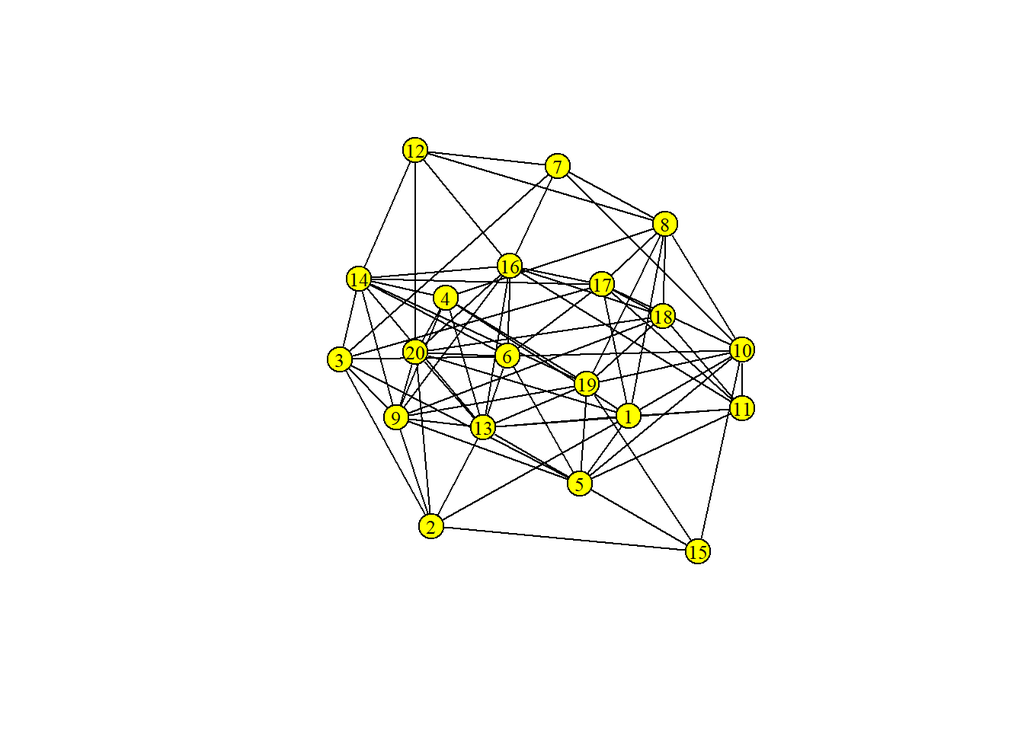

```r
g1 = getrandomgraph(20, 0.5)
```

```r
num_columns = length(g1[1])
num_rows = num_columns
adjacency_matrix = matrix(NA, nrow = num_rows, ncol = num_columns)
for (r in 1:num_rows) {
  adjacency_matrix[r,] = g1[r]
}
#for these iterations we do not print the adjacency matrix because it could be large
#print(adjacency_matrix)

out <- maxcut(adjacency_matrix)
optimal_max_cut = -out$pobj
print(optimal_max_cut)
```

```
## [1] 55.5509
```

```r
max_cut_simulation_run(number_of_simulations = 20,
                       adjacency_matrix = adjacency_matrix,
                       optimal_max_cut = optimal_max_cut)
```

```
## [1] "The randomazied max cut algorithm average is higher than half of the optimal max cut value"
```

```
## [1] 38.95
```

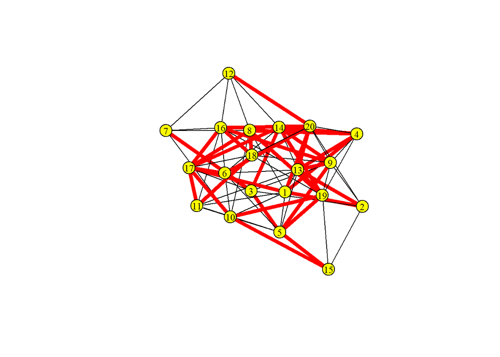

```r
cuts = randomized_max_cut(adjacency_matrix = adjacency_matrix)$cutted_edges
show_cuts_in_graph(g1, cuts)
```

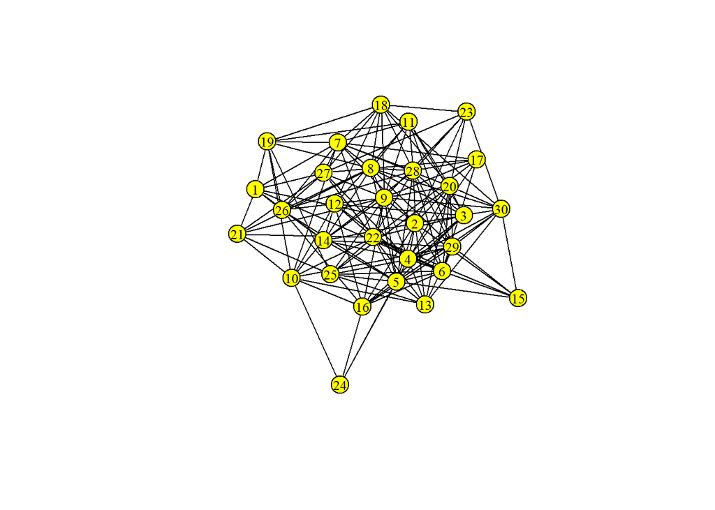

```r
g1 = getrandomgraph(30, 0.4)
```

```r
num_columns = length(g1[1])
num_rows = num_columns
adjacency_matrix = matrix(NA, nrow = num_rows, ncol = num_columns)
for (r in 1:num_rows) {
  adjacency_matrix[r,] = g1[r]
}
#for these iterations we do not print the adjacency matrix because it could be large
#print(adjacency_matrix)

out <- maxcut(adjacency_matrix)
optimal_max_cut = -out$pobj
print(optimal_max_cut)
```

```
## [1] 111.5195
```

```r
max_cut_simulation_run(number_of_simulations = 20,
                       adjacency_matrix = adjacency_matrix,
                       optimal_max_cut = optimal_max_cut)
```

```
## [1] "The randomazied max cut algorithm average is higher than half of the optimal max cut value"
```

```
## [1] 80.3
```

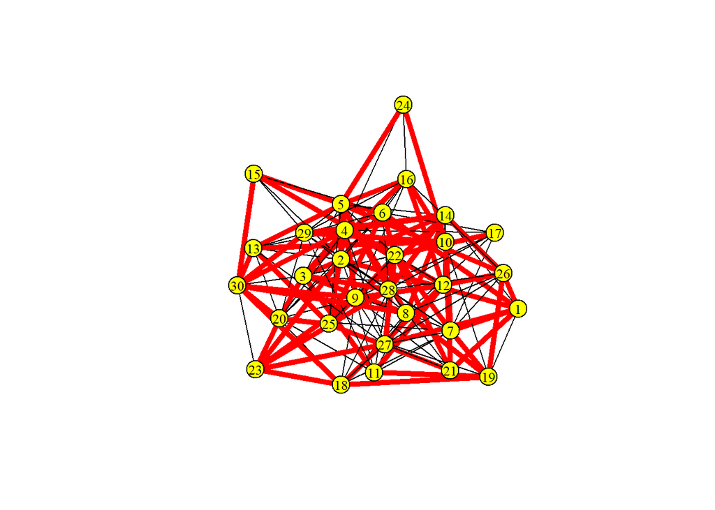

```r
cuts = randomized_max_cut(adjacency_matrix = adjacency_matrix)$cutted_edges
show_cuts_in_graph(g1, cuts)
```

## A quick review with a summary table

[output not shown]

In the last part, we report a plot about the the algorithm’s performance for an increasing number of iterations in order to calculate the optimal number of cuts.  
As you can see, as the number of iterations increases, the value converges to an average value with less variance.

```r
result = rep(NA, length(seq(1, 1000, by=10)))
count = 0
for (i in seq(1, 1000, by=10)){
  count = count + 1
  result[count] <- max_cut_simulation_run(number_of_simulations = i,
                                          adjacency_matrix = adjacency_matrix,
                                          optimal_max_cut = optimal_max_cut, print= FALSE)

}
```

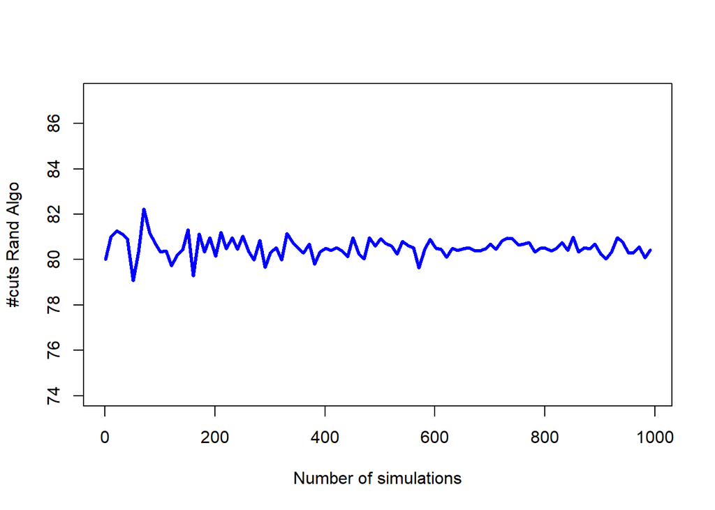

```r
plot(seq(1, 1000, by=10), result, xlab="Number of simulations",
     ylab="#cuts Rand Algo", type='l',
     ylim=c(min(result)-5, max(result)+5),
     col='blue', lwd=3)
```

# Part B ~ Power Law Distribution

In this second part of the homework we will be looking into the distribution of a randomly simulated directed graph. Specifically we will try to show that this graph follows a power law distribution, meaning that pages (nodes) with higher degree of links tend to have more and more in links as the number of pages (nodes) increases.

The power law distribution is characterized as follows:

$$\begin{align}
y = c \cdot x^{\alpha}
\end{align}$$

which on the log-log scale can be expressed as:

$$\begin{align}
log(y) = \alpha \cdot log(x) + log(c)
\end{align}$$

We will later on show how our $k_{in}$ distribution (represents the number of in links a node has) has a very high $R^{2}$ value over this log-log scale.

```r
paste(getwd(), '/Images')
```

```
## [1] "C:/Users/juanm/Documents/Master/Data Science/Statistical_Methods_Data_Science_Lab/Project/Homework 1 /Images"
```

```r
list.files(paste(getwd(), '/Images'))
```

```
## character(0)
```

## Preferential Attachment Process Algorithm

The logic behind our code implementation is basically the construction of a 2*n matrix in which the first column represents the node from where the link goes out, and the second column represents the node where the link goes in.

This representation of our “adjacency matrix” allows us to compute links more efficiently than using an n*n matrix in which most of the elements would be zero (representing no link between two nodes). This representation also allowed us to easily compute probabilities for the new pages. When $\gamma<0.5$ we would simply sample from the first column (all nodes are equally likely to get selected for a new incoming link). Instead, when $\gamma>0.5$ we would sample from the second column (where it would be more probable to select nodes that appear more frequently).

Once the complete 2*n matrix we generated we would flatten the matrix to obtain a vector which would then be provided as input for the graph generation.

Below you can find the code described:

```r
model_network = function(input_matrix, number_of_nodes, gamma) {
  adjm = input_matrix[order(input_matrix[,2]),]
  for (i in nrow(input_matrix)+1:number_of_nodes) {
    if (i%%10000 == 0) {
      print(i)
    }
    # Generate random value (0 or 1 with equal probabilities) to see where we
    # attach the new page link to (if all nodes will be weighted equally or if
    # nodes with more in-degrees will have higher weights)
    coin = runif(1)

    if (coin >= gamma) {
      in_node = sample(adjm[,1],
                       size=1,
                       replace=FALSE)
    } else {
      # Unique nodes with link
      unique_nodes_in_link = adjm[,2]

      in_node = sample(unique_nodes_in_link,
                       size=1,
                       replace=FALSE)
    }

    adjm = rbind(adjm, c(i, in_node))

  }
  output = list('flat_adjm' = as.vector(t(adjm)),
                'adjm' = adjm)

  return(output)

}
```

Given the flat adjacency and the full adjacency matrix we could start constructing the graphs and the probability functions of the $k_{in}$ degree distribution. This is constructed using the table function, resulting a two arrays:

1. **k_in_degree_values:** Number of times a given number of $k_{in}$ links is present
2. **probability:** Probability of a node having a certain number of $k_{in}$ links $P(n=k)$ (probability that node n has k $k_{in}$ links).

We will shortly see that the probability of a node having 1 $k_{in}$ link is huge compared to the probability of having higher number of $k_{in}$ links.

We then apply our function several times to generate different simulations, as can be seen below (our networks are only of size 100000 since 1million pages took to long to generate the plot).

```r
pages = 100000

for(i in 1:7) {

  print(i)

  nam <- paste("network_", i, sep = "")
  flat_adjm <- paste("flat_adjm_", i, sep = "")

  initial_matrix = matrix(data=0, nrow=4, ncol=2)
  initial_matrix[1,] = c(1, 2)
  initial_matrix[2,] = c(2, 3)
  initial_matrix[3,] = c(3, 4)
  initial_matrix[4,] = c(4, 1)

  assign(nam, model_network(initial_matrix, pages, 0.5))
  assign(flat_adjm, eval(parse(text=paste0('network_', i,'$flat_adjm'))))
  adjm = eval(parse(text=paste0('network_', i,'$adjm')))
  g = eval(parse(text=paste0('make_directed_graph(',flat_adjm, ')')))

  # Number of times a given number of k_in links is present (ordered)
  k_in_degree_values = as.numeric(names(table(table(adjm[,2]))))
  #
  probability = as.numeric((table(table(adjm[,2]))))/sum(as.numeric((table(table(adjm[,2])))))
  cdf = cumsum(probability)

  png(file=paste0("sim_", i, "_network.png"), width=600, height=350)

  plot(g, edge.arrow.size=.1, vertex.color="black", vertex.size=.5,
       vertex.frame.color="black", vertex.label.color="black",
       vertex.label.cex=0.8, edge.curved=0,
       vertex.label=NA)

  dev.off()

  png(file=paste0("sim_", i, "_dist_normal.png"), width=600, height=350)

  plot(k_in_degree_values, probability, type = "b", pch = 19,
       col = "blue", xlab = "k_in degree", ylab = "Frequency (prob of k)")
  curve(dpois(x, mean(adjm[,2])),
        from = 0, to = max(k_in_degree_values),
        n = max(k_in_degree_values) + 1,
        col = 'green', add = TRUE, lwd = 3, type='l')
  legend("topright", inset = 0.02, legend=c("K in degree Distribution",
                                            "Poisson Distribution"),
         col=c("blue", "green"), lty=1:2, cex=0.8,
         box.lty=0)

  dev.off()

  png(file=paste0("sim_", i, "_dist_log_log.png"), width=600, height=350)

  plot(k_in_degree_values, probability, type = "b", pch = 19,
       col = "blue", xlab = "k_in degree", ylab = "Frequency (prob of k)",
       log="xy")

  dev.off()

  png(file=paste0("sim_", i, "_dist_log_log_cum.png"), width=600, height=350)

  plot(k_in_degree_values, cdf, type = "b", pch = 19,
       col = "blue", xlab = "k_in degree", ylab = "Cumulative Frequency (cdf of k_in degrees)",
       log="xy")

  dev.off()

}
```

#### Simulation 1

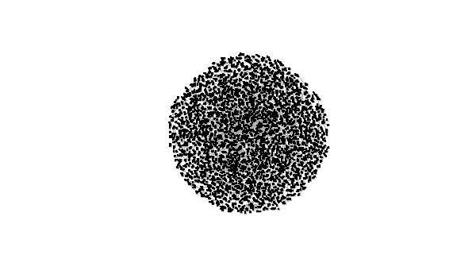

Simulation 1 Network

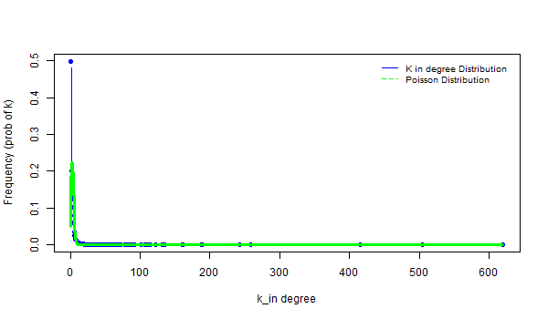

Simulation 1 Probability Mass Function with Poisson Distribution

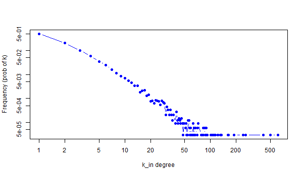

Simulation 1 Probability Mass Function over log-log axis

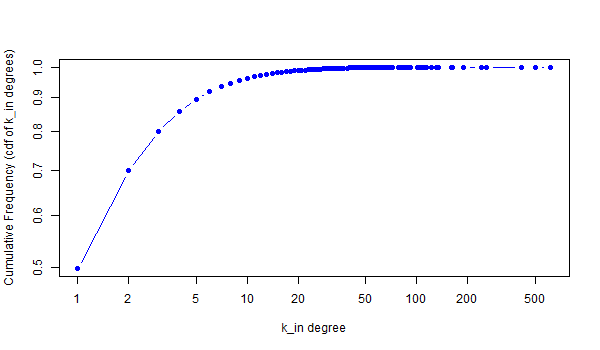

Simulation 1 Cumulative Distribution

*Results for the remaining simulations can be found in the appendix*

We can clearly see how the Poisson distribution does not match the $k_{in}$ distribution, confirming our initial hypothesis. Instead, from the log-log scale plot we can see how it very much behaves like a straight line.

In order to prove that the log-log scale behaves like a straight line we will look into its linear regression using the following piece of code:

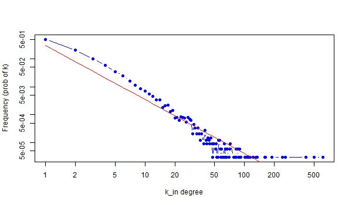

Log-Log Linear Fit

| R-squared | Slope (alpha) | Intercept (c) |
| --- | --- | --- |
| 0.8657 | -1.204 | -1.933 |

```r
fit_vector = network_1$adjm
k_in_degree_values = as.numeric(names(table(table(fit_vector[,2]))))
#
probability = as.numeric((table(table(fit_vector[,2]))))/sum(as.numeric((table(table(fit_vector[,2])))))

png(file=paste0("log_log_fit.png"), width=600, height=350)

plot(k_in_degree_values, probability, , type = "b", pch = 19,
     col = "blue", xlab = "k_in degree", ylab = "Frequency (prob of k)",
     log="xy")


# Fit the linear models on the logarithms of x and y
dts <- data.frame(logx=log(k_in_degree_values), logy=log(probability))
fit <- lm(logy~logx, data=dts)

# Plot the linear model
dts$predlogy <- predict(fit, newdata=dts)
lines(exp(dts$logx), exp(dts$predlogy), col='red')

dev.off()
```

From the previous table we can say that the $k_{in}$ distribution fits a straight line with a high probability ($R^{2} = 0.86$).

## Appendix

### Simulation 2

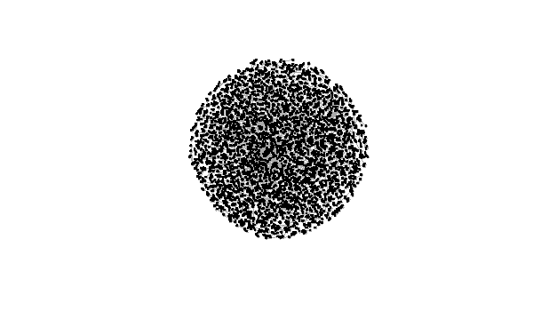

Simulation 2 Network

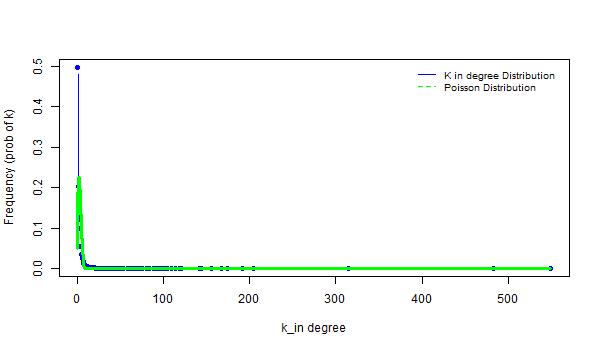

Simulation 2 Probability Mass Function with Poisson Distribution

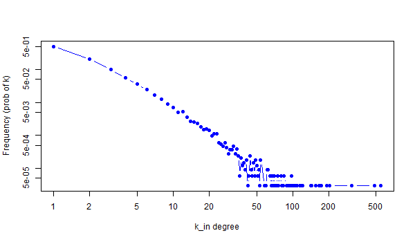

Simulation 2 Probability Mass Function over log-log axis

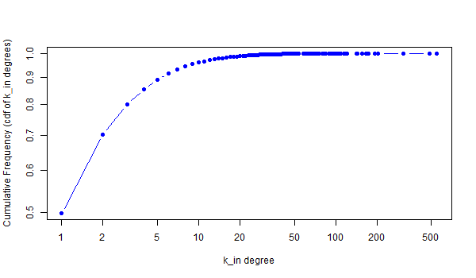

Simulation 2 Cumulative Distribution

### Simulation 3

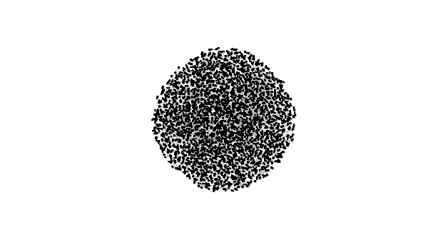

Simulation 3 Network

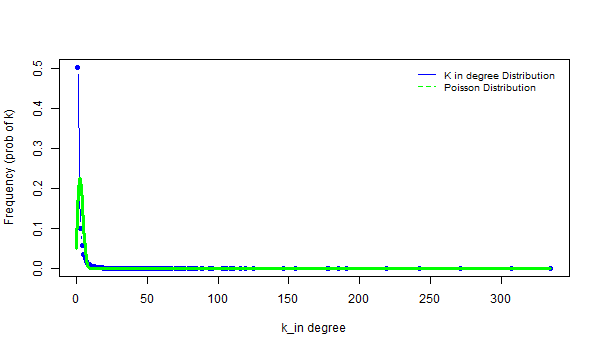

Simulation 3 Probability Mass Function with Poisson Distribution

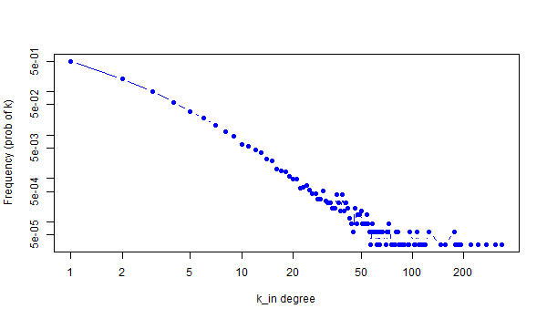

Simulation 3 Probability Mass Function over log-log axis

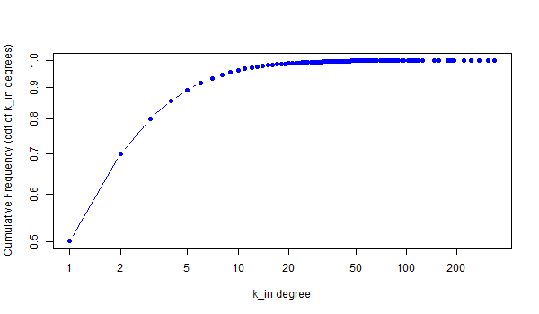

Simulation 3 Cumulative Distribution

### Simulation 4

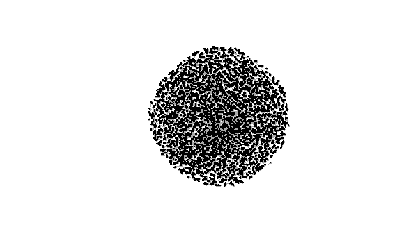

Simulation 4 Network

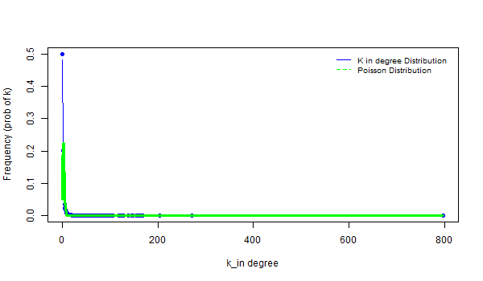

Simulation 4 Probability Mass Function with Poisson Distribution

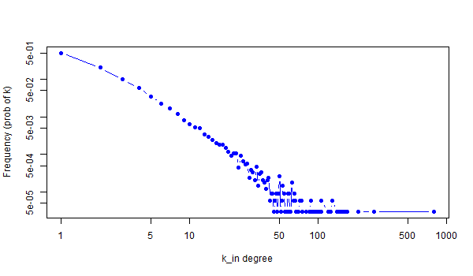

Simulation 4 Probability Mass Function over log-log axis

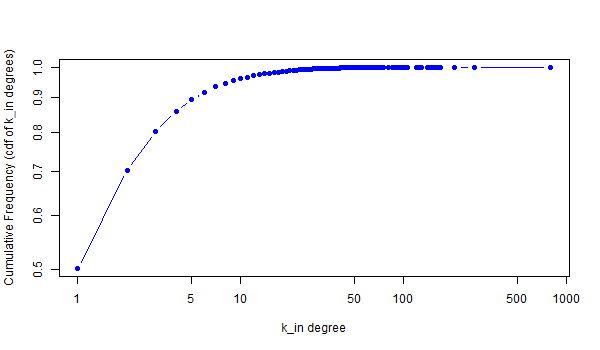

Simulation 4 Cumulative Distribution

### Simulation 5

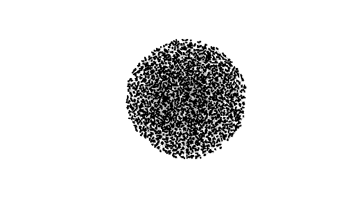

Simulation 5 Network

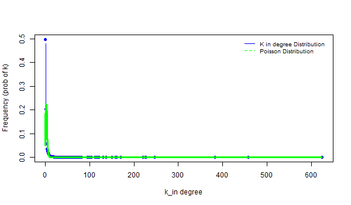

Simulation 5 Probability Mass Function with Poisson Distribution

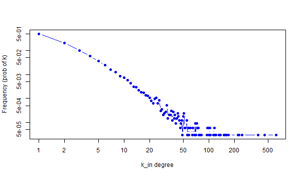

Simulation 5 Probability Mass Function over log-log axis

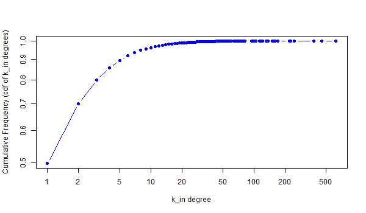

Simulation 5 Cumulative Distribution

### Simulation 6

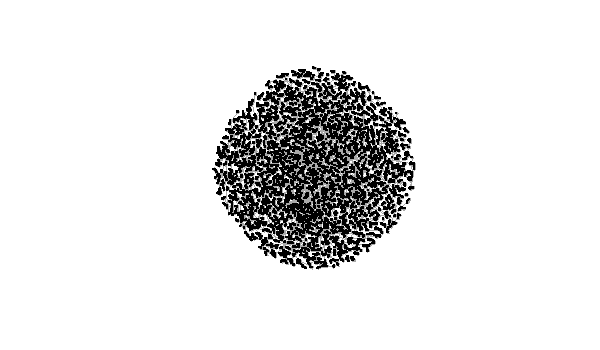

Simulation 6 Network

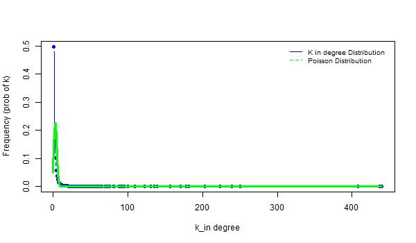

Simulation 6 Probability Mass Function with Poisson Distribution

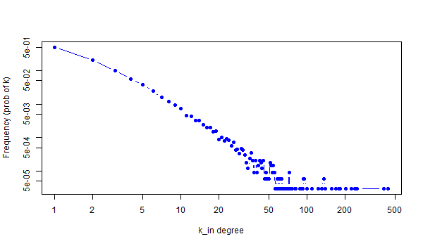

Simulation 6 Probability Mass Function over log-log axis

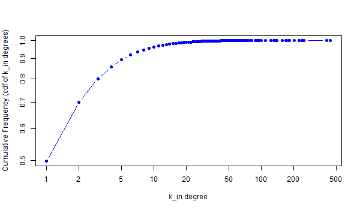

Simulation 6 Cumulative Distribution

### Simulation 7

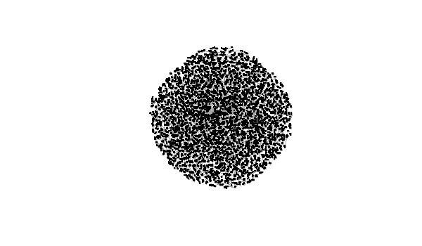

Simulation 7 Network

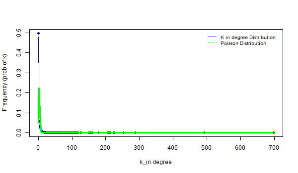

Simulation 7 Probability Mass Function with Poisson Distribution

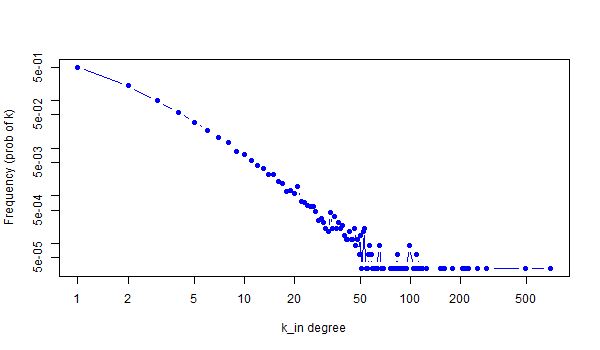

Simulation 7 Probability Mass Function over log-log axis

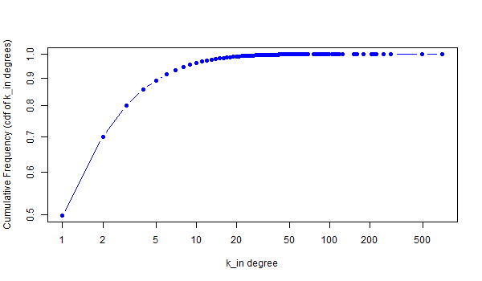

Simulation 7 Cumulative Distribution